# Anticipating resurgence

Leading indicators for vaccine-preventable disease

John M. Drake

Regents’ Professor, Odum School of Ecology & Center for the Ecology of Infectious Diseases, University of Georgia

Department of Epidemiology

Columbia University Mailman School of Public Health

October 1, 2026

## Collaborators

Pej Rohani

Suzanne O’Regan

Tobias Brett

Eamon O’Dea

Amy Winter

Andrew Tredennick

Mallory Harris

Bogdan Epureanu

Amin Ghadami

Shiyang Chen

Paige Miller

Matt Ferrari

Andrew Park

Fabian Dablander

## Measles has resurged three times in eleven years

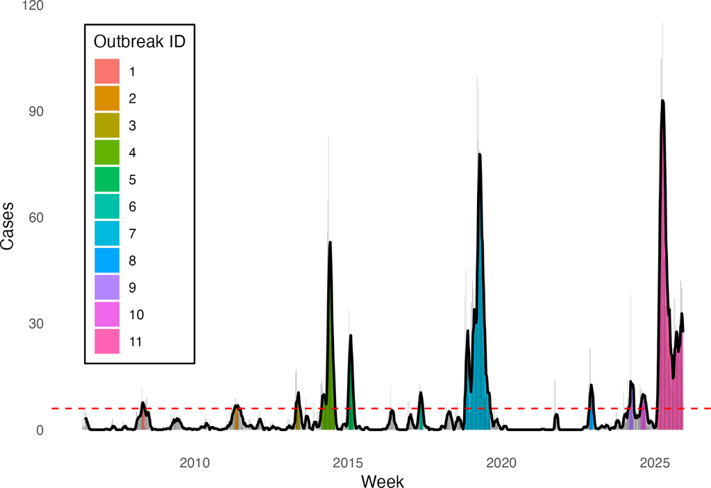

Weekly US measles cases, 2006–2025, show three major outbreaks: 2014, 2018–19 and 2025. Drake & Rohani, Future Microbiol 2026.

## Resurgence looks sudden because the threshold is crossed before the cases arrive

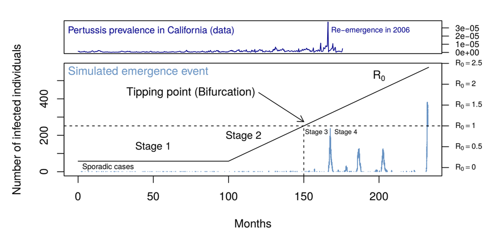

In a simulation matched to California’s 2006 pertussis resurgence, the tipping point (R<sub>0</sub> = 1) comes roughly a year before cases take off. O’Regan & Drake, Theor Ecol 2013.

## Early warning belongs in the watch and warning phases of epidemic intelligence

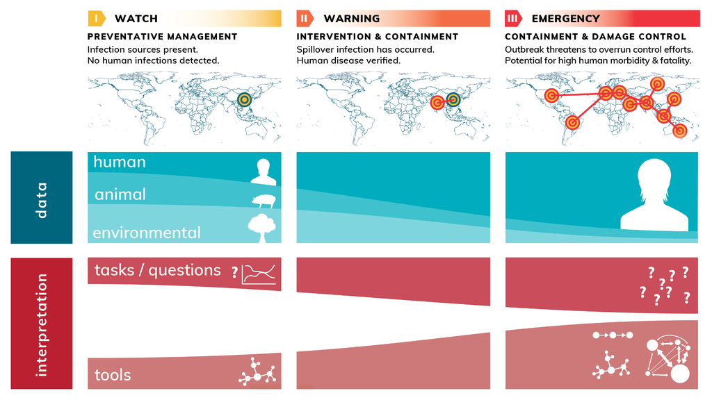

Epidemic intelligence has three phases (watch, warning and emergency), and each calls for different data, questions and tools. After Han & Drake, EMBO Rep 2016.

## The plan for today

1. Why the approach to R = 1 should be detectable
2. Whether the signal holds up in messy surveillance data
3. Where it has worked
4. US measles, where it didn’t
5. What that failure teaches us

# Why the threshold is detectable

## A system losing resilience recovers from shocks more slowly

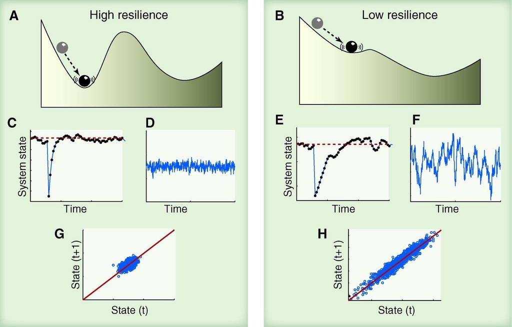

A ball in a shallow basin returns slowly after a push, so its trajectory becomes more variable and more autocorrelated. Scheffer et al., Science 2012.

## For measles, herd immunity leaves almost no margin

$$R_e = R_0 \, \frac{S}{N} \qquad\qquad p_c = \frac{1 - 1/R_0}{E}$$

| $R_0$ | basic reproduction number: secondary cases from one infection in a wholly susceptible population |
| --- | --- |
| $R_e$ | effective reproduction number in the current population |
| $S/N$ | fraction of the population susceptible |
| $p_c$ | critical vaccination coverage |
| $E$ | vaccine efficacy against infection |

## Declining vaccination is a slow driver acting on fast transmission

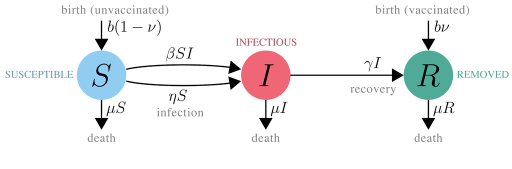

$$\dot S = \mu(1-p) - \beta S I - \eta S - \mu S \qquad \dot I = \beta S I + \eta S - (\gamma + \mu) I$$

$$\dot p = \epsilon f(S, I, R), \qquad 0 < \epsilon \ll 1$$

## Stochastic transmission is described exactly by a master equation

$$\frac{dP(\sigma, t)}{dt} = \sum_{\tilde\sigma \ne \sigma} T(\sigma \mid \tilde\sigma)\, P(\tilde\sigma, t) - \sum_{\tilde\sigma \ne \sigma} T(\tilde\sigma \mid \sigma)\, P(\sigma, t)$$

Transitions from $\sigma = (S, I)$ go to $(S{+}1, I{-}1)$, $(S{-}1, I)$, $(S{+}1, I)$, $(S, I{-}1)$ or $(S, I{+}1)$.

O’Regan & Drake, Theor Ecol 2013.

## The van Kampen expansion turns the fluctuations into a linear Fokker–Planck equation

$$S = N\phi_S + \sqrt{N}\,\xi_S, \qquad I = N\phi_I + \sqrt{N}\,\xi_I$$

$$\frac{\partial \Pi(\xi, t)}{\partial t} = -\sum_{i,j} A_{ij} \frac{\partial (\xi_j \Pi)}{\partial \xi_i} + \frac{1}{2}\sum_{i,j} B_{ij} \frac{\partial^2 \Pi}{\partial \xi_i \partial \xi_j}$$

The mean field gives the deterministic model; the fluctuations are Gaussian, with covariance set by the Jacobian $A$.

System-size expansion from statistical physics: van Kampen, Adv Chem Phys 1976.

## At $R_0 = 1$, return time, variance and autocorrelation all diverge

$$\Lambda = \beta - (\gamma + \mu) \;\to\; 0 \quad \text{as} \quad R_0 \to 1$$

- Characteristic return time $\tau \approx -1/\Lambda$ diverges (a linear approximation, valid only near the critical point)
- Variance diverges
- Lag-one autocorrelation goes to one

O’Regan & Drake 2013; Drake et al., PLOS Comput Biol 2019.

## Near the critical immunization level, the potential well goes flat

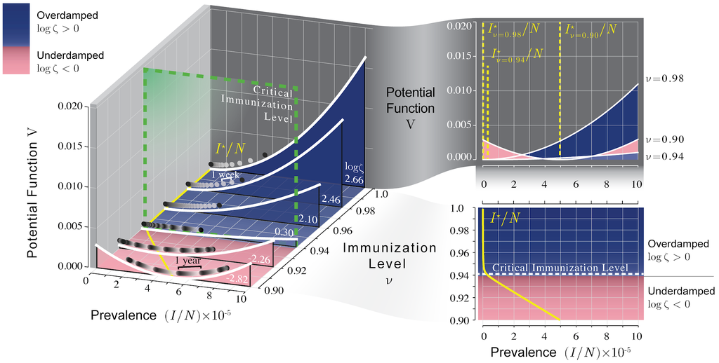

The potential function of the SIR model with vaccination at immunization levels from 90% to 100%; the well is flattest at the critical level (about 94%), where R<sub>e</sub> = 1. Drake et al., PLOS Comput Biol 2019.

## Near the threshold, the indicators have simple closed forms

| Indicator | Formula |
| --- | --- |
| Mean | $\mu_1 = \dfrac{\zeta/\gamma}{1 - R_0}$ |
| Variance | $\sigma^2 = \dfrac{\zeta/\gamma}{(1 - R_0)^2}$ |
| Index of dispersion | $\sigma^2/\mu_1 = \dfrac{1}{1 - R_0}$ |
| Coefficient of variation | $\sigma/\mu_1 = (\zeta/\gamma)^{-1/2}$ |
| Autocorrelation | $AC(\tau) = \exp\!\big(-(1 - R_0)\gamma\tau\big)$ |

Birth–death–immigration process with sparking rate ζ. Brett, Drake & Rohani, J R Soc Interface 2017.

## In simulation, variance and autocorrelation rise before herd immunity is lost

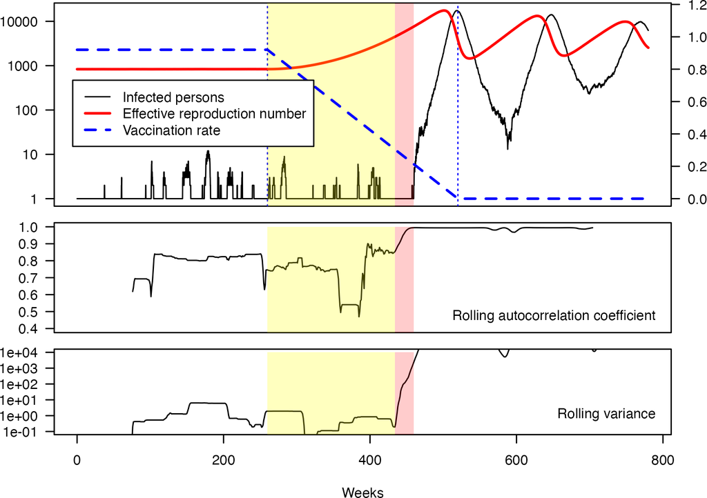

In a city of 8.5 million that starts 92% protected, vaccination declines (blue) and R<sub>e</sub> rises (red); rolling autocorrelation and variance climb before the outbreak. Drake, Rohani & Winter, Future Microbiol 2026.

# Does the signal hold up in surveillance data?

## Case reports are aggregated and noisy versions of the true dynamics

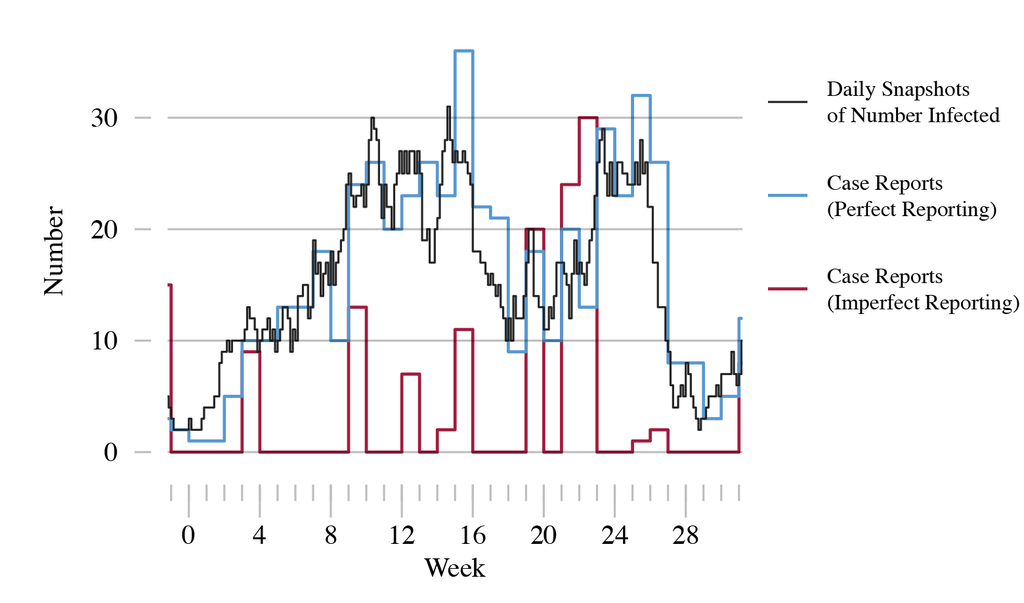

True infections (black) differ from perfect weekly reports (blue) and from reports with sampling error (red). Brett et al., PLOS Comput Biol 2018.

## Most indicators still work under realistic reporting

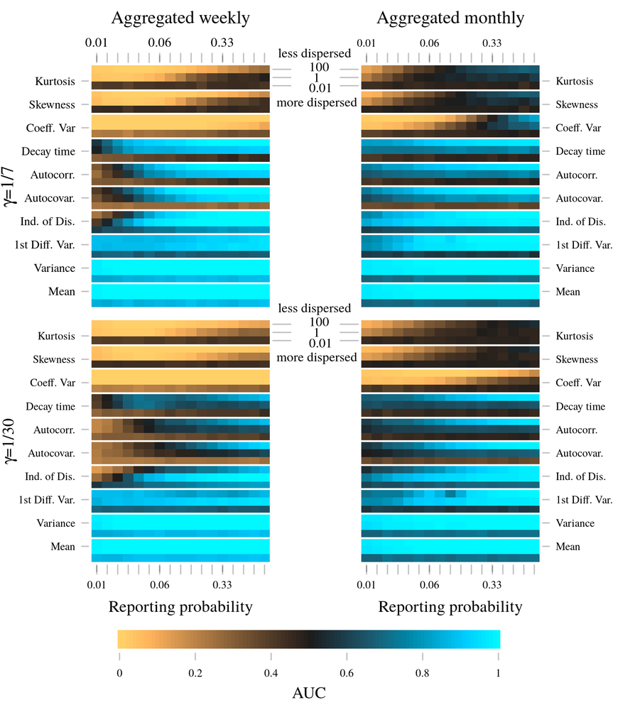

Seven of ten indicators keep high AUC unless reporting error is highly overdispersed. Brett et al. 2018.

## Seasonal forcing doesn’t erase critical slowing down

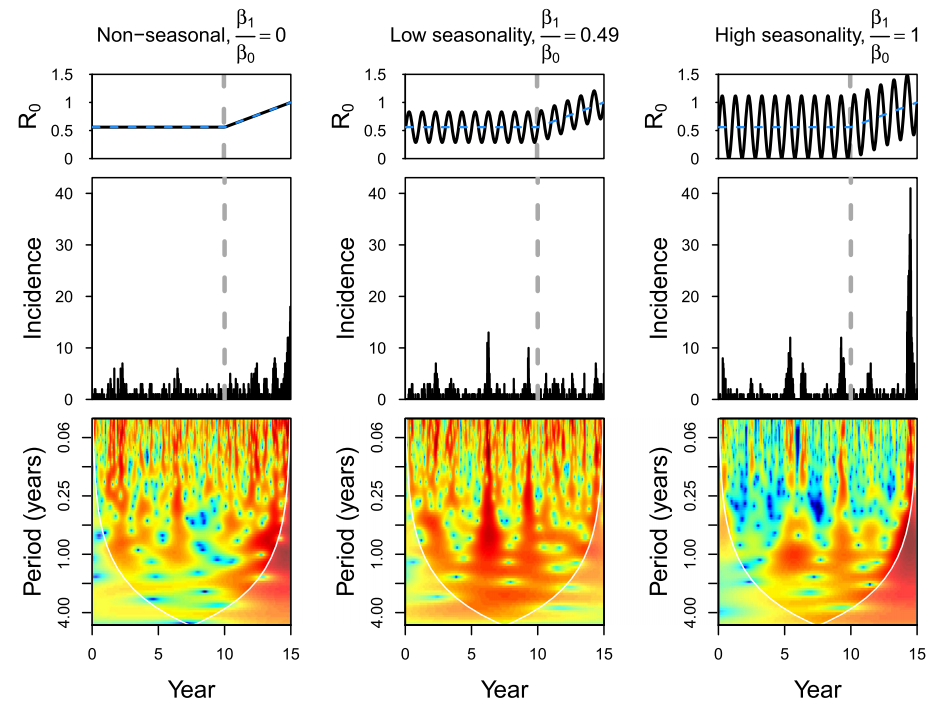

Simulated emergence with no, low and high seasonality, with wavelet power below. Miller et al. 2017.

## Wavelet filtering stays reliable as seasonality grows

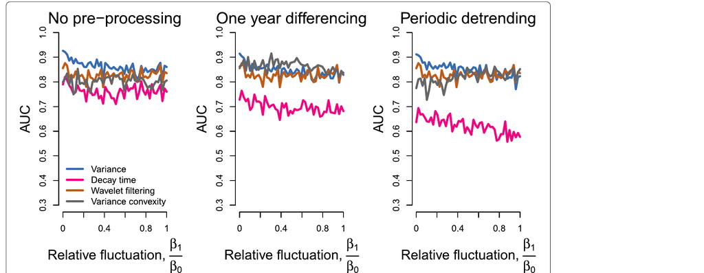

AUC of the top indicators against seasonal amplitude β₁/β₀, under three kinds of preprocessing. Miller et al., Theor Biol Med Model 2017, Fig. 3.

## Early warning signals appear even in models too complex to analyze

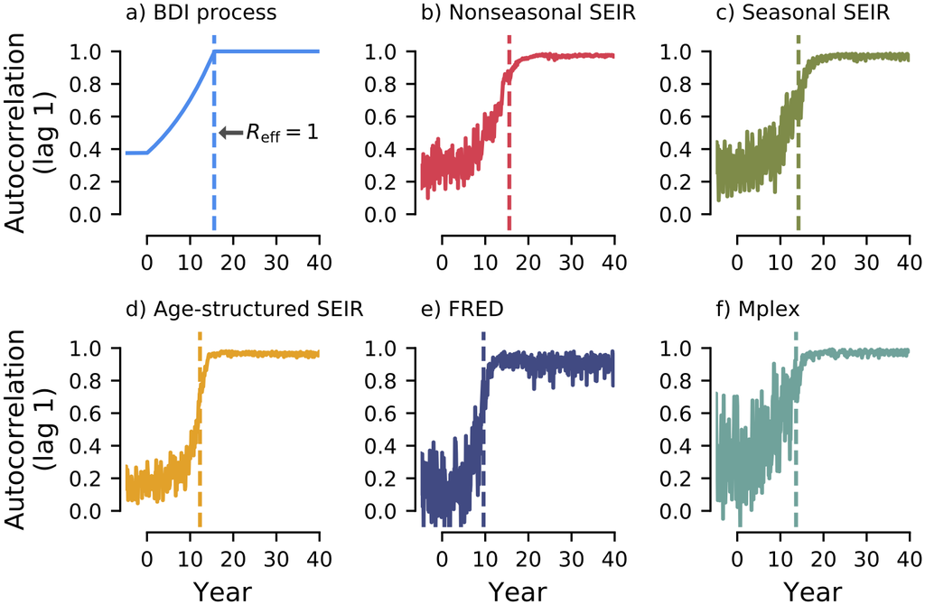

Lag-one autocorrelation rises before R<sub>eff</sub> = 1 in six models, from a birth–death process to the FRED agent-based simulation. Brett et al., PLOS Comput Biol 2020.

# Where it has worked

## Malaria in Kenya’s western highlands resurged after years of control

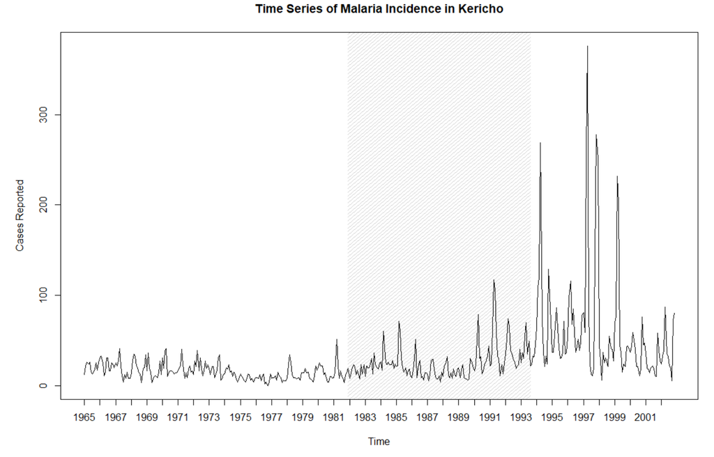

Monthly malaria cases at a tea estate in Kericho, Kenya, 1965–2002. Harris, Hay & Drake, Biol Lett 2020.

## Four indicators warned of Kericho’s resurgence two years ahead

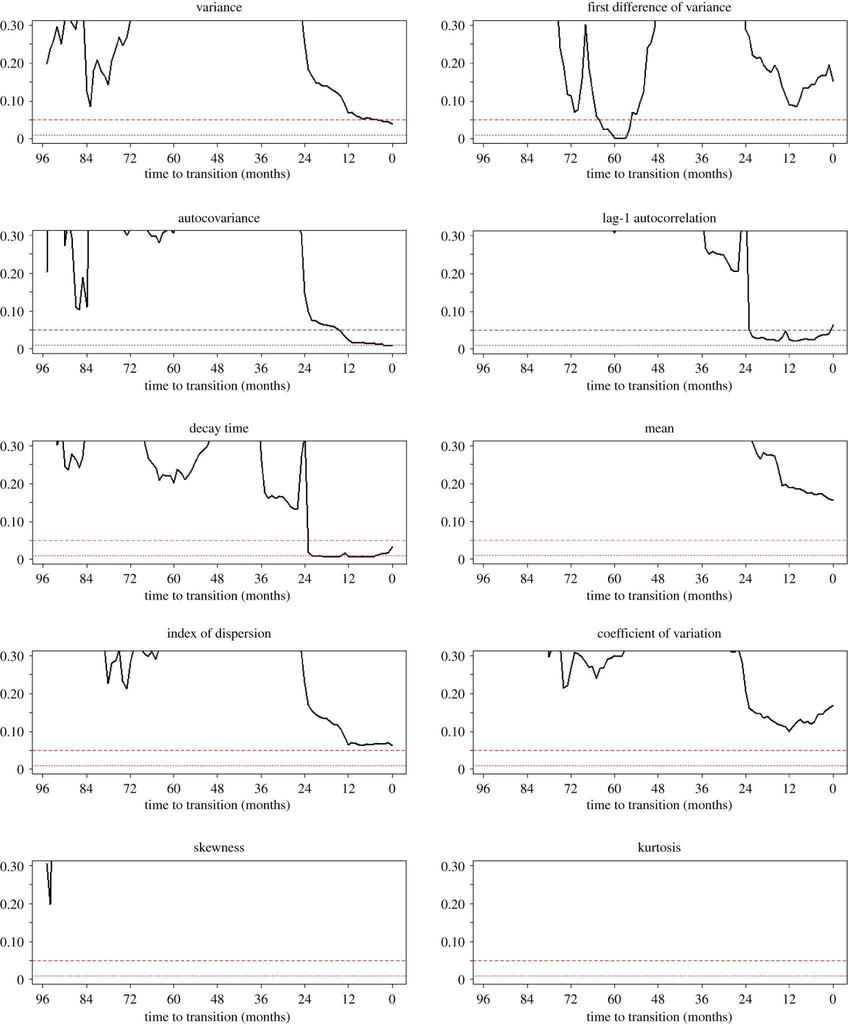

Four indicators became significant about 24 months before the transition. Harris, Hay & Drake 2020.

## Variance rose before the 1983 monkeypox epidemic in Central and West Africa

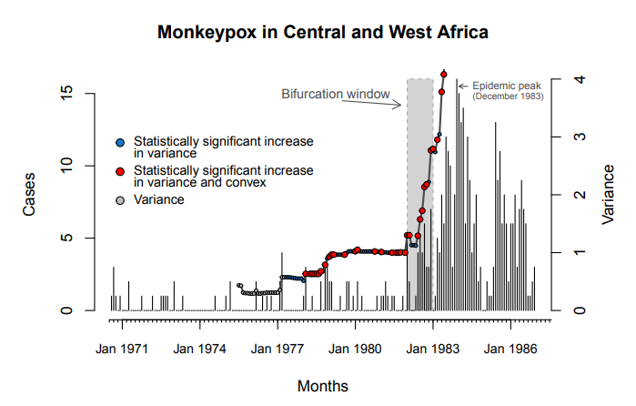

Statistically significant increases in variance appear in the bifurcation window. Unpublished analysis.

## Signals have also appeared before mumps and pertussis resurgence

- **Mumps, England:** a combined decision function rose about four years before the 2004–05 outbreak
- **Pertussis, US states:** resurgent states were distinguishable from non-resurgent ones by the early 1990s
- **Measles, Niger:** variance and autocorrelation rose before re-emergence and elimination in model-constrained simulations

Brett & Rohani, PLOS Biol 2020; Tredennick et al., J R Soc Interface 2022.

## For COVID-19, overlapping timescales scrambled the signal

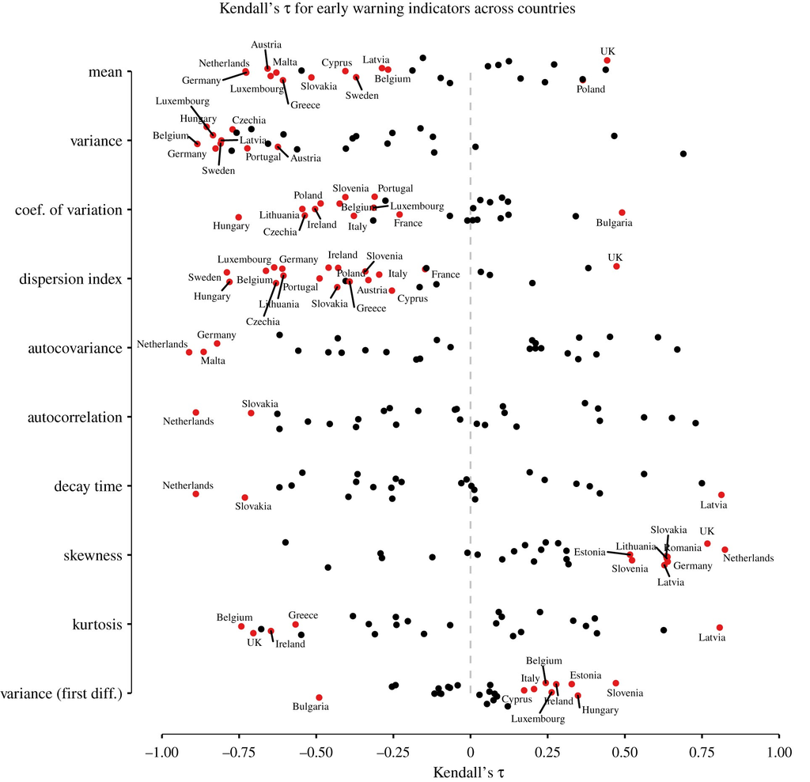

Indicator trends before Europe’s second COVID-19 wave point both ways across countries. Dablander et al. 2022.

# US measles, 2006–2025

## Three outbreaks stand out against years of near-zero incidence

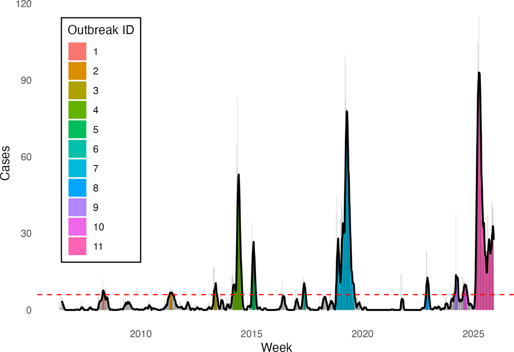

Weekly US measles cases, 2006–2025. Colored areas are the 11 outbreaks; the dashed line is the 6-cases-per-week threshold used to define them. Drake & Rohani 2026.

## We tested whether variance and autocorrelation rose before three major outbreaks

- Weekly cases, 2006–2025, from a curated domestic dataset plus CDC NNDSS
- Rolling-window variance and lag-one autocorrelation (our open-source R package)
- Trend tests with Spearman’s ρ adjusted for autocorrelation
- Sensitivity grid: 3 detrending × 3 window bandwidths

Drake & Rohani, Future Microbiol 2026.

## Neither indicator rose consistently before any of the three outbreaks

Autocorrelation showed a weak positive trend over the full series, significant only under some detrending choices. Variance showed none.

In the windows before 2014, 2018–19 and 2025, neither increased consistently.

Apparent signals appeared only with very large bandwidths and weren’t robust. Drake & Rohani, Future Microbiol 2026.

## Outbreaks didn’t get larger or longer on the way to 2025

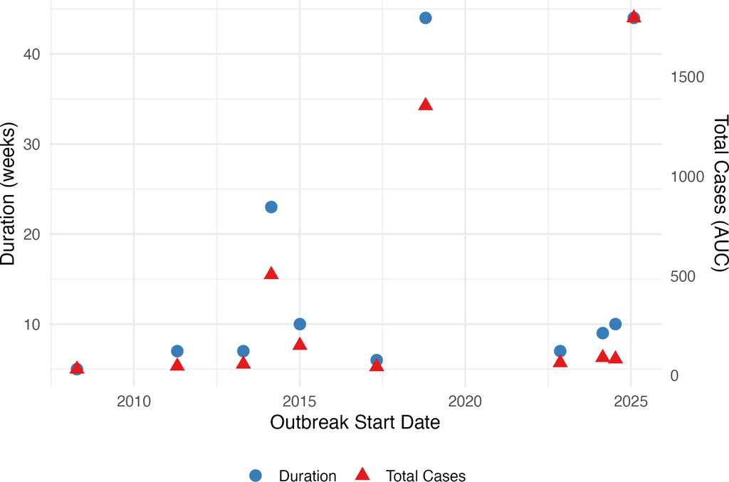

Outbreak duration (r = 0.44, p = 0.18) and size (r = 0.47, p = 0.16) show no trend with start date. Drake & Rohani, Future Microbiol 2026.

## Fade-outs stayed as frequent as ever

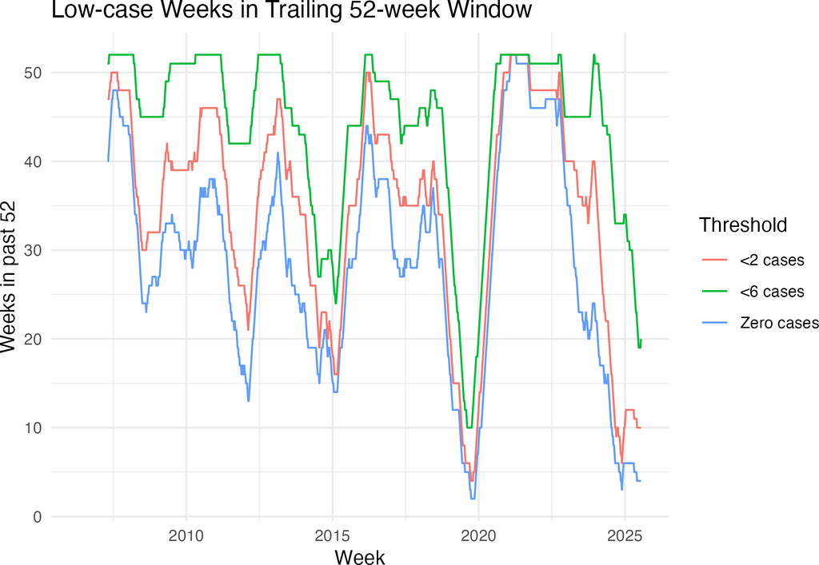

The number of weeks with zero, fewer than two, or fewer than six cases in a trailing 52-week window shows no secular decline. Drake & Rohani, Future Microbiol 2026.

## Four explanations for the missing signal

1. **Direction.** Approach from below is intrinsically harder to detect.
2. **Hovering, not drifting.** The US may sit in a weakly subcritical regime.
3. **Response.** Outbreak control truncates the dynamics the theory describes.
4. **Aggregation.** National totals average over asynchronous local dynamics.

# What it will take

## Outbreak response has to be part of the model

Theory treats outbreak size as intrinsic dynamics, but for measles every outbreak is truncated by case finding, exclusion and vaccination campaigns.

## We need to tell drifting from hovering

The same outbreak record can come from a system sliding toward R = 1 or one idling just below it.

## Signals will be local before they are national

Immunity gaps are concentrated in schools, counties and communities, so indicators should be computed where transmission happens.

## Evidence is still thin, and a warning isn’t a decision

- Only 16 of 37 studies of resilience indicators for outbreaks used real data
- Few show an unambiguous rise in routine surveillance before an outbreak
- Action thresholds must weigh the asymmetric costs of false alarms and misses

Delecroix et al., PLOS Glob Public Health 2023; Drake, Rohani & Winter, Future Microbiol 2026.

## The approach to resurgence should be detectable; for US measles, so far, it hasn’t been

The work now is closing the gap between the theory and the way public health surveillance and response actually operate.

## Acknowledgments

Pej Rohani, Andrew W. Park, Bogdan Epureanu, Matt Ferrari, Eamon O’Dea, Shiyang Chen, Eric Marty, Paige Miller, Tobias S. Brett, Amin Ghadami, Mallory Harris, Suzanne O’Regan, Fabian Dablander, Hans Heesterbeek, Denny Borsboom, Andrew Tredennick, Amy Winter, Shaun Truelove

Supported by NSF award 2426740; NSF Predictive Intelligence for Pandemic Prevention award 2200158; and NIGMS/NIH award U01GM110744 (MIDAS). The content is solely the responsibility of the authors.

## References (1 of 3)

- Brett TS, Drake JM, Rohani P. 2017. Anticipating the emergence of infectious diseases. *J R Soc Interface* 14:20170115.
- Brett TS, O’Dea EB, Marty É, Miller PB, Park AW, Drake JM, Rohani P. 2018. Anticipating epidemic transitions with imperfect data. *PLOS Comput Biol* 14:e1006204.
- Brett TS, Ajelli M, Liu Q-H, Krauland MG, Grefenstette JJ, van Panhuis WG, Vespignani A, Drake JM, Rohani P. 2020. Detecting critical slowing down in high-dimensional epidemiological systems. *PLOS Comput Biol* 16:e1007679.
- Brett TS, Rohani P. 2020. Dynamical footprints enable detection of disease emergence. *PLOS Biol* 18:e3000697.
- Chen S, O’Dea EB, Drake JM, Epureanu BI. 2019. Eigenvalues of the covariance matrix as early warning signals for critical transitions in ecological systems. *Sci Rep* 9:2572.
- Dablander F, Heesterbeek H, Borsboom D, Drake JM. 2022. Overlapping timescales obscure early warning signals of the second COVID-19 wave. *Proc R Soc B* 289:20211809.
- Delecroix C, van Nes EH, van de Leemput IA, Rotbarth R, Scheffer M, ten Bosch Q. 2023. The potential of resilience indicators to anticipate infectious disease outbreaks, a systematic review and guide. *PLOS Glob Public Health* 3:e0002253.

## References (2 of 3)

- Drake JM, Brett TS, Chen S, Epureanu BI, Ferrari MJ, Marty É, Miller PB, O’Dea EB, O’Regan SM, Park AW, Rohani P. 2019. The statistics of epidemic transitions. *PLOS Comput Biol* 15:e1006917.
- Drake JM, Rohani P. 2026. No evidence for critical slowing down before measles outbreaks in the US, 2006–2025. *Future Microbiol* 21:135–140.
- Drake JM, Rohani P, Winter A. 2026. Can vaccine-preventable disease resurgence be anticipated? Leading indicators and tipping points. *Future Microbiol* 21:321–327.
- Ghadami A, O’Dea EB, Drake JM, Rohani P, Epureanu BI. 2023. Anticipating epidemic transitions in metapopulations with multivariate spectral similarity. *Nonlinear Dyn* 111:17605–17615.
- Han BA, Drake JM. 2016. Future directions in analytics for infectious disease intelligence: toward an integrated warning system for emerging pathogens. *EMBO Rep* 17:785–789.
- Harris MJ, Hay SI, Drake JM. 2020. Early warning signals of malaria resurgence in Kericho, Kenya. *Biol Lett* 16:20190713.
- Kaul RB, Evans MV, Murdock CC, Drake JM. 2018. Spatio-temporal spillover risk of yellow fever in Brazil. *Parasit Vectors* 11:488.

## References (3 of 3)

- Miller PB, O’Dea EB, Rohani P, Drake JM. 2017. Forecasting infectious disease emergence subject to seasonal forcing. *Theor Biol Med Model* 14:17.
- O’Dea EB, Drake JM. 2019. Disentangling reporting and disease transmission. *Theor Ecol* 12:89–98.
- O’Dea EB, Drake JM. 2022. A semi-parametric, state-space compartmental model with time-dependent parameters for forecasting COVID-19 cases, hospitalizations and deaths. *J R Soc Interface* 19:20210702.
- O’Regan SM, Drake JM. 2013. Theory of early warning signals of disease emergence and leading indicators of elimination. *Theor Ecol* 6:333–357.
- O’Regan SM, O’Dea EB, Rohani P, Drake JM. 2020. Transient indicators of tipping points in infectious diseases. *J R Soc Interface* 17:20200094.
- Scheffer M, Carpenter SR, Lenton TM, et al. 2012. Anticipating critical transitions. *Science* 338:344–348.
- Tredennick AT, O’Dea EB, Ferrari MJ, Park AW, Rohani P, Drake JM. 2022. Anticipating infectious disease re-emergence and elimination: a test of early warning signals using empirically based models. *J R Soc Interface* 19:20220123.
- van Kampen NG. 1976. The expansion of the master equation. *Adv Chem Phys* 34:245–309.

# Backup

## The second factorial moment separates rising transmission from rising reporting

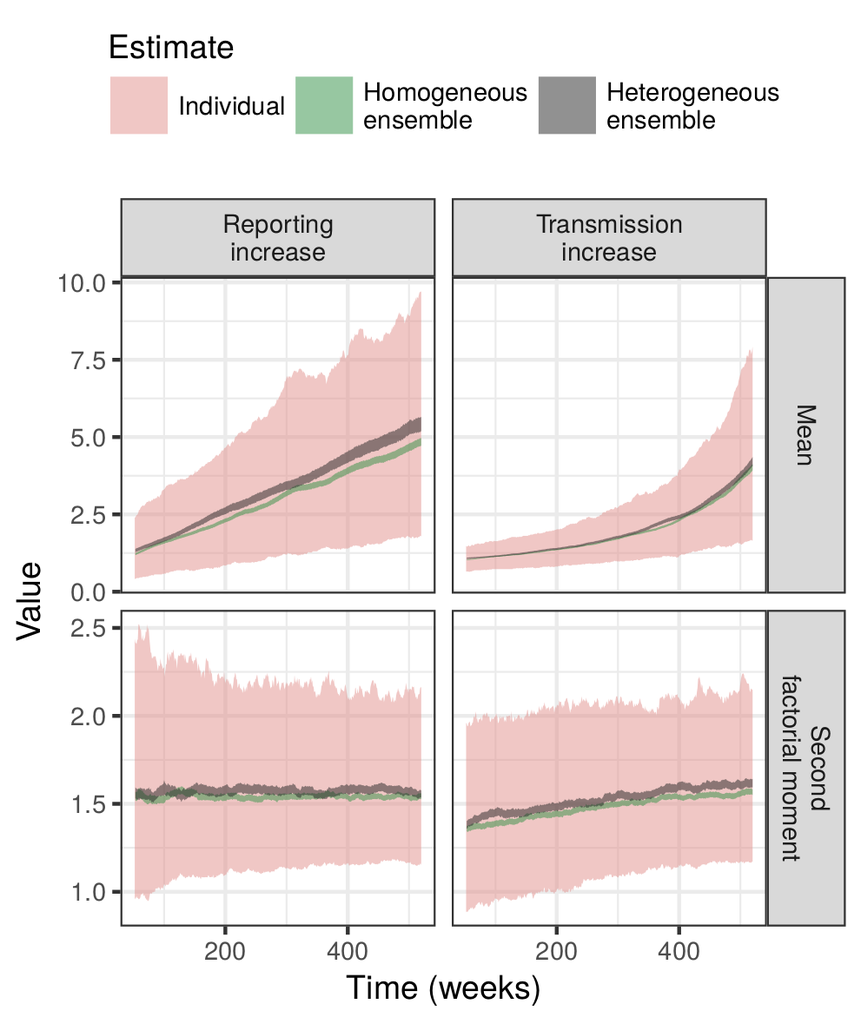

The mean rises whether reporting or transmission increases; the second factorial moment rises only with transmission. O’Dea & Drake, Theor Ecol 2019.

## Resurgence is harder to see coming than elimination

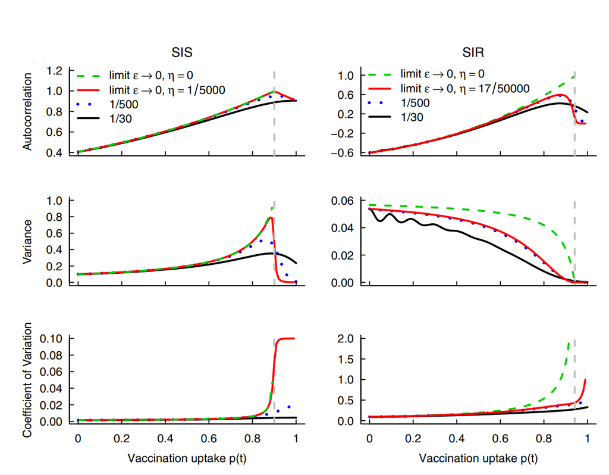

**Elimination:** coverage rising

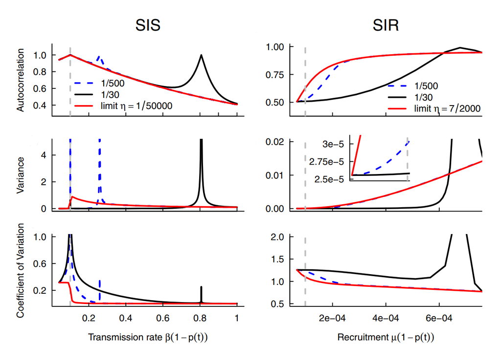

**Emergence:** coverage falling

Theoretical indicators from the van Kampen expansion for SIS and SIR models. O’Regan & Drake, Theor Ecol 2013.

## Each phase needs its own analytical tool

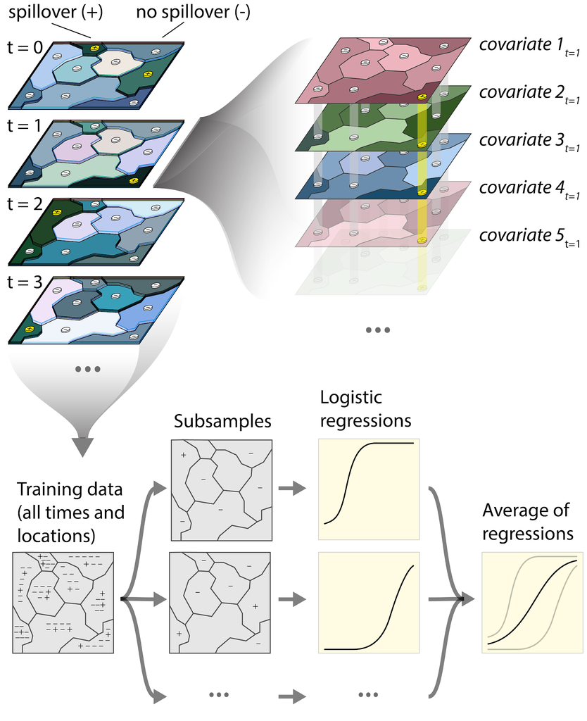

**Watch:** spillover risk mapping

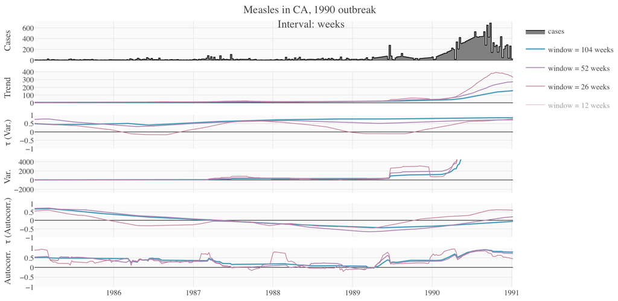

**Warning:** early warning signals

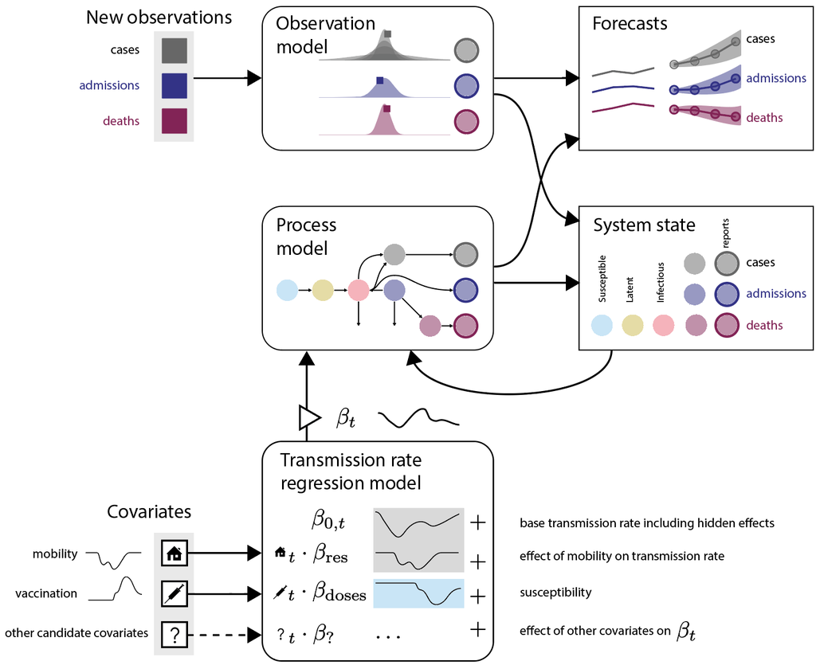

**Emergency:** forecasting

Kaul et al. 2018; Drake et al. 2019; O’Dea & Drake 2022.

## Wavelet filtering ranks with variance; wavelet reddening degrades with seasonality

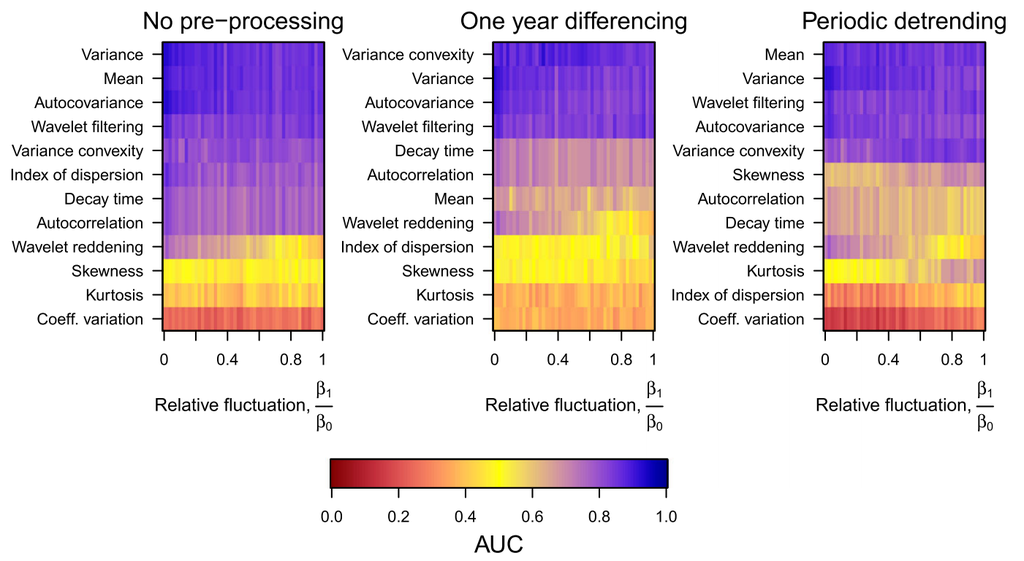

AUC of each indicator across seasonal amplitude under three kinds of preprocessing. Miller et al., Theor Biol Med Model 2017.

## Pertussis spectra across US states converged as vaccination pushed toward the threshold

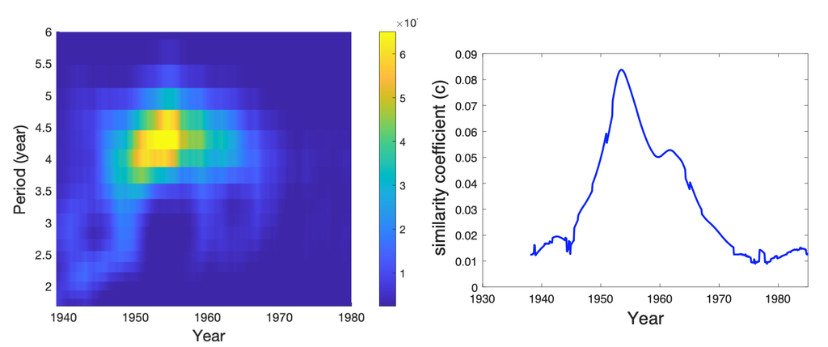

Multivariate spectral similarity of state-level pertussis series, 1938–1980. Ghadami et al., Nonlinear Dyn 2023.

## Trajectories spiral more slowly toward equilibrium near the critical immunization level

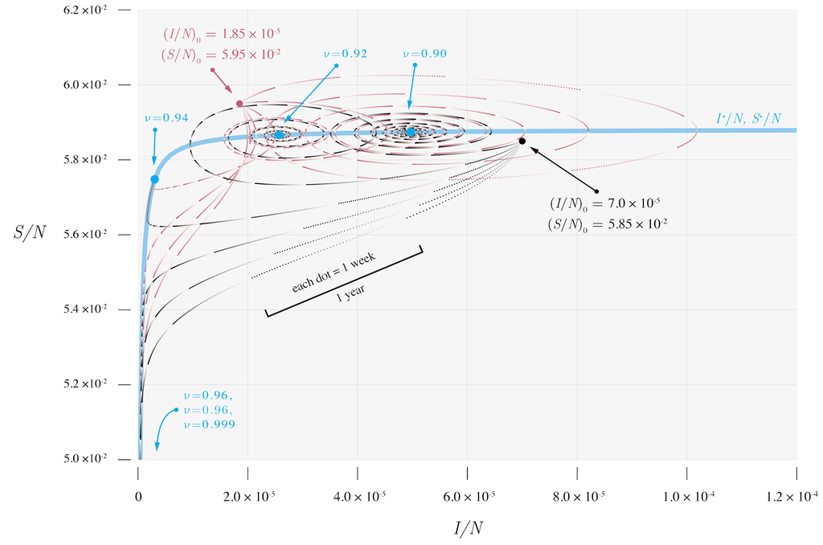

Deterministic SIR solutions in S–I phase space for six immunization levels and two initial conditions. Drake et al., PLOS Comput Biol 2019.

## Critical slowing down precedes emergence in the hinge model

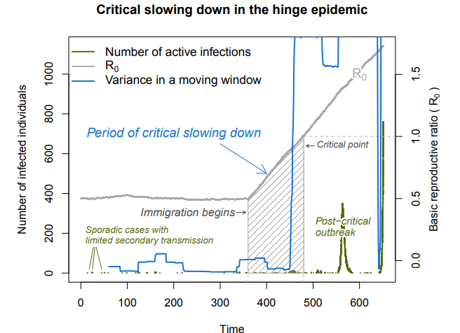

Variance in a moving window rises through a period of critical slowing down before the critical point. Unpublished.

## Autocorrelation slows as vaccination drives transmission toward elimination

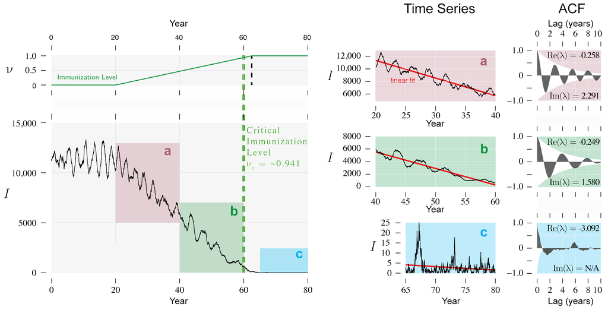

Oscillations in the autocorrelation function lengthen as vaccine uptake approaches the critical level. Drake et al., PLOS Comput Biol 2019.

## Emergence rate can be estimated by maximum likelihood

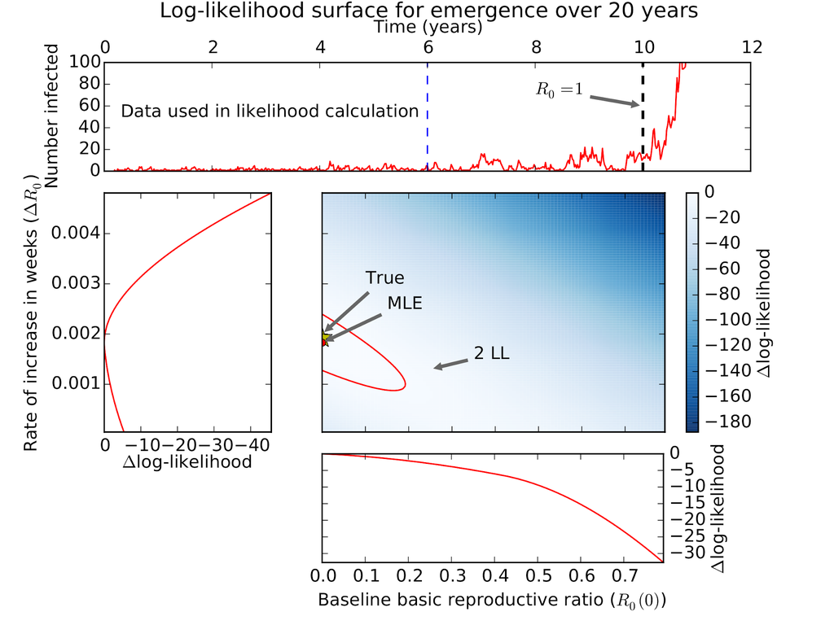

The likelihood surface from the first six years of a simulated emergence recovers the true rate of increase in R<sub>0</sub>. Brett, Drake & Rohani, J R Soc Interface 2017.

## Indicator performance depends on window size and transition speed

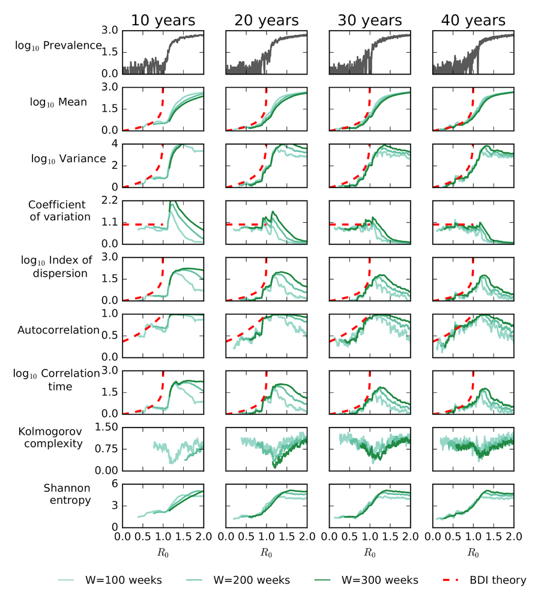

Indicators under 10- to 40-year approaches; red is stationary BDI theory. Brett, Drake & Rohani 2017.